# Analysis of Firms Experiment

Elea McDonnell Feit

1/18/2018

# Data

The data describes an experiment where respondents where given a story about a company that either did or did not take a stand regarding an abortion-related law. Each row describes the story that was given to the repondent and their evaluation of the company.

- **stand** of a firm with respect to the law was either “against”, “for” or “none” (randomly manipulated)
- **firm.value** was either “results”-oriented or “values”-oriented (randomly manipulated)
- **hypocricy** is a measure of the level of perceived corporate hypocrisy. It is a composite of three perceived hypocrisy scale items.
- **purchase_int** is the composite score of three purchase intention scale items.
- **age** is the age of the respondent.
- **gender** is the gender of the respondent.

```r
d <- read.csv("firms.csv")
d$stand <- as.factor(d$stand)
d$firm.value <- as.factor(d$firm.value)
d$gender <- as.factor(d$gender)
summary(d)
```

```
##       stand      firm.value   hypocrisy      purchase_int
##  against :58   results:85   Min.   :1.000   Min.   :1.000
##  for     :59   values :88   1st Qu.:1.330   1st Qu.:3.330
##  no stand:56                Median :2.330   Median :4.330
##                             Mean   :2.917   Mean   :4.235
##                             3rd Qu.:4.000   3rd Qu.:5.670
##                             Max.   :7.000   Max.   :7.000
##       age           gender
##  Min.   :19.00   female:82
##  1st Qu.:28.00   male  :91
##  Median :33.00
##  Mean   :37.43
##  3rd Qu.:46.00
##  Max.   :69.00
```

# Outliers

After inspecting the data, we realized that observation 30 was incorrectly collected, so we remove them.

```r
d <- d[-30,]
summary(d)
```

```
##       stand      firm.value   hypocrisy      purchase_int
##  against :58   results:85   Min.   :1.000   Min.   :1.000
##  for     :58   values :87   1st Qu.:1.330   1st Qu.:3.248
##  no stand:56                Median :2.330   Median :4.330
##                             Mean   :2.921   Mean   :4.225
##                             3rd Qu.:4.000   3rd Qu.:5.670
##                             Max.   :7.000   Max.   :7.000
##       age           gender
##  Min.   :19.00   female:82
##  1st Qu.:28.00   male  :90
##  Median :33.00
##  Mean   :37.43
##  3rd Qu.:46.00
##  Max.   :69.00
```

# Analysis

We hypothesize that when values-oriented (versus results-oriented) companies abstain from taking a political stand, consumers perceive them to be hypocritical. This, in turn, will lead to lower purchase intention for the products offered by those companies. Based on this hypothesis, we created a new variable indicating whether the firm was described as taking a stand.

```r
d$stand.yn <- as.character(d$stand)
d$stand.yn[d$stand.yn=="against" | d$stand.yn=="for"] <- "stand"
d$stand.yn <- as.factor(d$stand.yn)
summary(d$stand.yn)
```

```
## no stand    stand
##       56      116
```

When value-oriented companies fail to take a stand, they are perceived as hypocritical

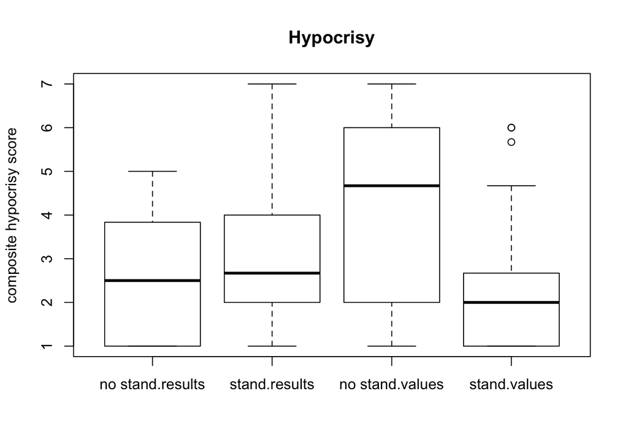

```r
boxplot(hypocrisy ~ stand.yn + firm.value, data=d, main="Hypocrisy", ylab="composite hypocrisy score")
```

Statistical significance of the interaction between stand.yn and firm.value is confirmed by ANOVA.

```r
m1 <- lm(hypocrisy ~ stand.yn*firm.value, data=d) # interactions
anova(m1)
```

```
## Analysis of Variance Table
##
## Response: hypocrisy
##                      Df Sum Sq Mean Sq F value    Pr(>F)
## stand.yn              1  26.78  26.777  10.312  0.001584 **
## firm.value            1   0.28   0.280   0.108  0.742879
## stand.yn:firm.value   1  70.48  70.481  27.143 5.479e-07 ***
## Residuals           168 436.24   2.597
## ---
## Signif. codes:  0 '***' 0.001 '**' 0.01 '*' 0.05 '.' 0.1 ' ' 1
```

Similarly, purchase intent is lower for those value-oriented firms who do not take a stand.

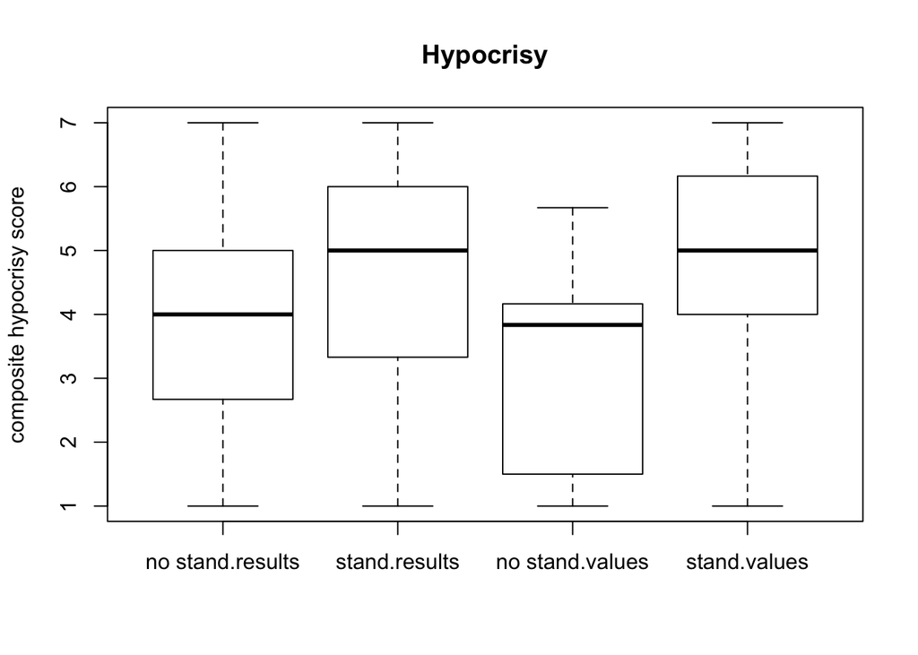

```r
boxplot(purchase_int ~ stand.yn + firm.value, data=d, main="Hypocrisy", ylab="composite hypocrisy score")
```

```r
m2 <- lm(purchase_int ~ stand.yn*firm.value, data=d)
anova(m2)
```

```
## Analysis of Variance Table
##
## Response: purchase_int
##                      Df Sum Sq Mean Sq F value    Pr(>F)
## stand.yn              1  45.03  45.032 15.4677 0.0001226 ***
## firm.value            1   0.33   0.326  0.1120 0.7382599
## stand.yn:firm.value   1   9.01   9.013  3.0957 0.0803179 .
## Residuals           168 489.11   2.911
## ---
## Signif. codes:  0 '***' 0.001 '**' 0.01 '*' 0.05 '.' 0.1 ' ' 1
```

I also did some simple t-tests for fun.

```r
t.test(d$hypocrisy[d$stand.yn=="no stand"], d$hypocrisy[d$stand.yn=="stand"])
```

```
##
##  Welch Two Sample t-test
##
## data:  d$hypocrisy[d$stand.yn == "no stand"] and d$hypocrisy[d$stand.yn == "stand"]
## t = 2.8295, df = 94.394, p-value = 0.005696
## alternative hypothesis: true difference in means is not equal to 0
## 95 percent confidence interval:
##  0.2511821 1.4328696
## sample estimates:
## mean of x mean of y
##  3.488750  2.646724
```

```r
p1 <- t.test(d$hypocrisy[d$stand.yn=="no stand"], d$hypocrisy[d$stand.yn=="stand"])$p.value
t.test(d$purchase_int[d$stand.yn=="no stand"], d$purchase_int[d$stand.yn=="stand"])
```

```
##
##  Welch Two Sample t-test
##
## data:  d$purchase_int[d$stand.yn == "no stand"] and d$purchase_int[d$stand.yn == "stand"]
## t = -4.0552, df = 118.91, p-value = 8.985e-05
## alternative hypothesis: true difference in means is not equal to 0
## 95 percent confidence interval:
##  -1.6251405 -0.5587635
## sample estimates:
## mean of x mean of y
##  3.488393  4.580345
```

```r
t.test(d$hypocrisy[d$firm.value=="results"], d$hypocrisy[d$firm.value=="values"])
```

```
##
##  Welch Two Sample t-test
##
## data:  d$hypocrisy[d$firm.value == "results"] and d$hypocrisy[d$firm.value == "values"]
## t = 0.32293, df = 168.54, p-value = 0.7471
## alternative hypothesis: true difference in means is not equal to 0
## 95 percent confidence interval:
##  -0.4454813  0.6197315
## sample estimates:
## mean of x mean of y
##  2.964941  2.877816
```

```r
t.test(d$purchase_int[d$firm.value=="results"], d$purchase_int[d$firm.value=="values"])
```

```
##
##  Welch Two Sample t-test
##
## data:  d$purchase_int[d$firm.value == "results"] and d$purchase_int[d$firm.value == "values"]
## t = -0.34981, df = 169.79, p-value = 0.7269
## alternative hypothesis: true difference in means is not equal to 0
## 95 percent confidence interval:
##  -0.6335379  0.4428063
## sample estimates:
## mean of x mean of y
##  4.176588  4.271954
```

The first test is significant at p= 0.0056958.

# Sample characteristics

The sample contains similar numbers of men and women.

```r
summary(d$gender)
```

```
## female   male
##     82     90
```

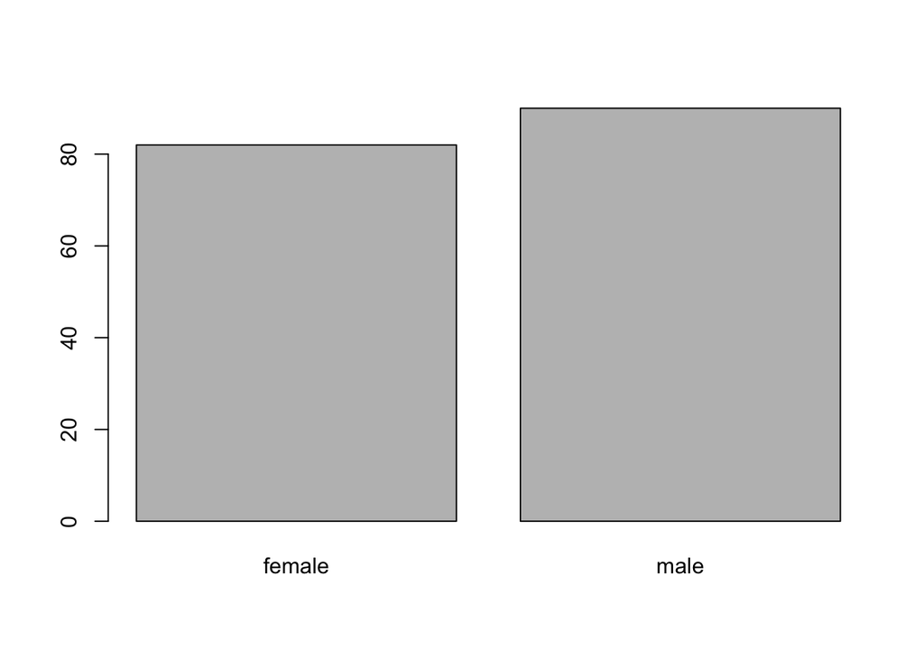

```r
plot(d$gender)
```

The distribution of age is typical for mTurk.

```r
summary(d$age)
```

```
##    Min. 1st Qu.  Median    Mean 3rd Qu.    Max.
##   19.00   28.00   33.00   37.43   46.00   69.00
```

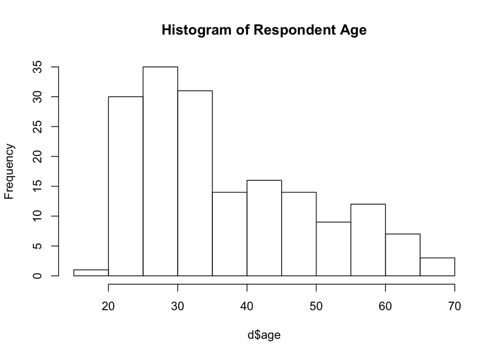

```r
hist(d$age, main="Histogram of Respondent Age")
```

# Randomization check

The proportion of women in each of the 6 (= 2 x 3) randomized treatments is similar with one exception.

```r
xtabs(~ gender + stand + firm.value, data=d)
```

```
## , , firm.value = results
##
##         stand
## gender   against for no stand
##   female       9  15       14
##   male        17  16       14
##
## , , firm.value = values
##
##         stand
## gender   against for no stand
##   female      15  15       14
##   male        17  12       14
```

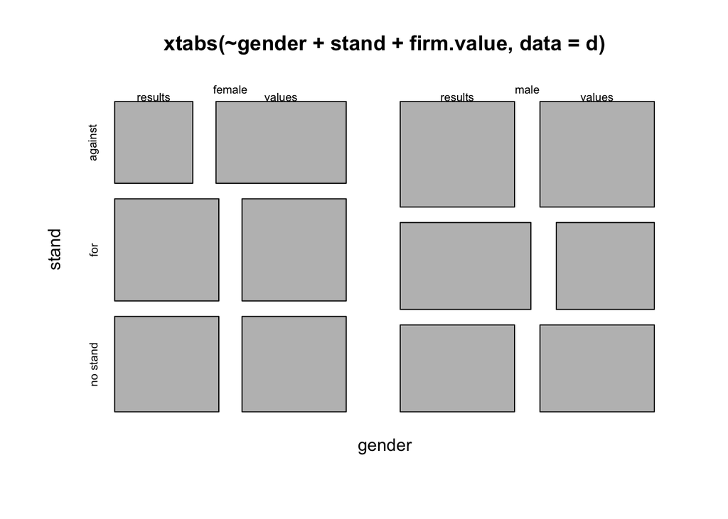

```r
plot(xtabs(~ gender + stand + firm.value, data=d))
```

The distribution of age is similar across the randomly assigned treatments, confirming that the randomization looks okay.

```r
aggregate(age ~ stand + firm.value, data=d, FUN=mean)
```

```
##      stand firm.value      age
## 1  against    results 39.15385
## 2      for    results 38.06452
## 3 no stand    results 37.35714
## 4  against     values 34.15625
## 5      for     values 38.96296
## 6 no stand     values 37.46429
```

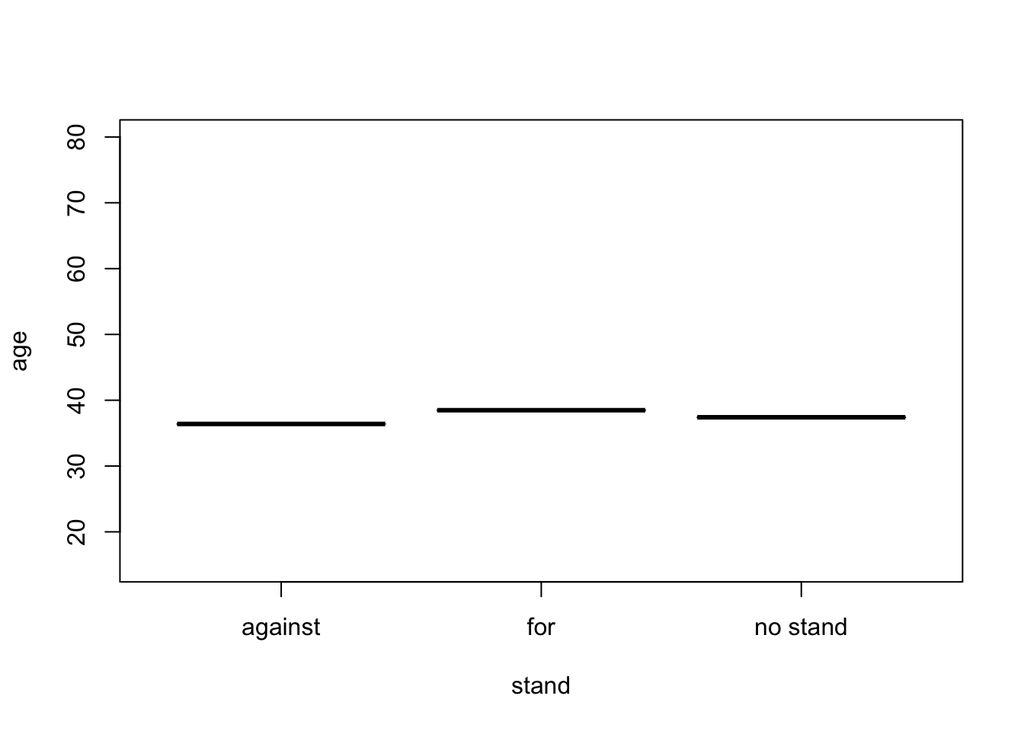

```r
plot(aggregate(age ~ stand, data=d, FUN=mean), ylim=c(15,80))
```

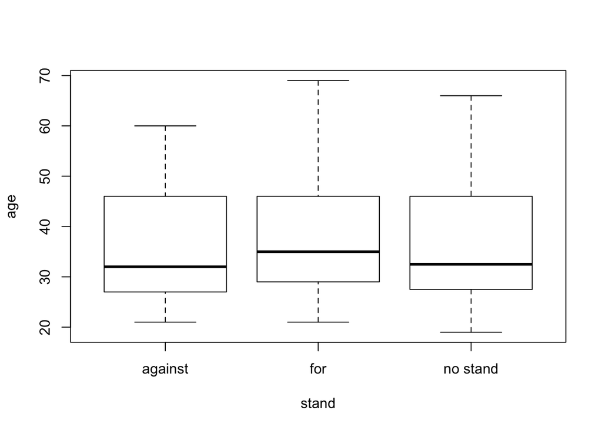

```r
plot(age ~ stand, data=d)
```